# Computer Assignment #5 Phase #2

## Ali Hamzehpour 810100129

## Convolutional Neural Networks

### Problem Description

In this phase, We are asked to create a convolutional neural network(CNN) to classify CIFAR-10 dataset which contains images of 10 different classes(airplanes, cars, birds, cats, deer, dogs, frogs, horses, ships, and trucks). We also have to implement Data Augmentation on an unbalanced data and in the end improve our model by using Dropout and Batch Normalization layers.

## Part 0: Loading data and Preprocessing

I load our data using `tensorflow.keras.datasets` which splits data to train and test by itself.

```python
from tensorflow.keras.datasets import cifar10

(X_train, y_train), (X_test, y_test) = cifar10.load_data()
```

```
Downloading data from https://www.cs.toronto.edu/~kriz/cifar-10-python.tar.gz
```

As you can see, we have 50000 images for train and 10000 images for test. Each images is 32*32 and They have color.(They are not gray-scale)

```python
print("X_train shape:", X_train.shape)
print("y_train shape:", y_train.shape)

print("X_test shape:", X_test.shape)
print("y_test shape:", y_test.shape)
```

```
X_train shape: (50000, 32, 32, 3)
y_train shape: (50000, 1)
X_test shape: (10000, 32, 32, 3)
y_test shape: (10000, 1)
```

I plot one image for each class to get a better understanding of our data.

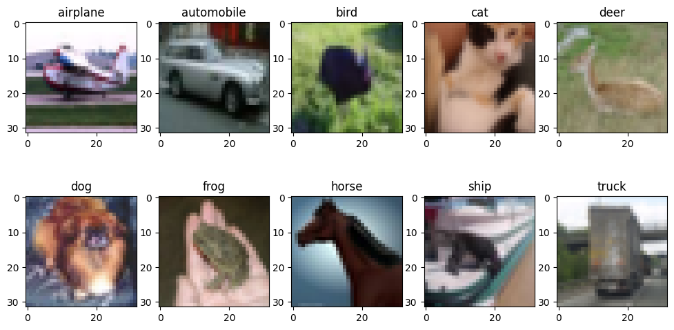

```python
import matplotlib.pyplot as plt
import numpy as np

class_names = ['airplane', 'automobile', 'bird', 'cat', 'deer',
               'dog', 'frog', 'horse', 'ship', 'truck']

fig, axes = plt.subplots(nrows=2, ncols=5, figsize=(12,6))

for i, ax in enumerate(axes.flat):
    idx = (y_train == i).nonzero()[0][np.random.randint(1, 100)]
    ax.imshow(X_train[idx])
    ax.set_title(class_names[i])

plt.show()
```

Then I have to normalize the images because the network can peform better and reach convergence faster with normalized data. I simply divide pixel values by 255 so the their range will be between 0 and 1.

```python
X_train = X_train / 255.0
X_test = X_test / 255.0
```

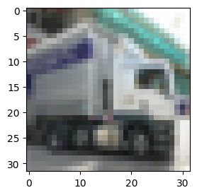

```python
plt.figure(figsize=(3,3))
plt.imshow(X_train[np.random.randint(len(X_train))])
plt.show()
```

I also have to encode our labels. I use "one-hot encoding". One-hot encoding is a process of converting categorical variables into a binary vector representation, where each vector corresponds to a unique category. In the one-hot encoding representation, only one element of the vector is 1, while all other elements are 0.

```python
from tensorflow.keras.utils import to_categorical
y_train_onehot = to_categorical(y_train)
y_test_onehot = to_categorical(y_test)
```

## Part 1: Image Classification with CNN

Now I make a CNN which it's structure is shown by the plot below:

```python
from tensorflow.keras.models import Sequential
from tensorflow.keras.layers import Dense, Conv2D, MaxPooling2D, Dropout, Activation, Input, Flatten
from tensorflow.keras.optimizers import Adam
from keras.utils import plot_model

def generate_simple_cnn(input_shape):
    cnn = Sequential()
    cnn.add(Conv2D(32, (3, 3), padding='same', activation="relu", input_shape=input_shape))
    cnn.add(Activation('relu'))
    cnn.add(Conv2D(32, (3, 3)))
    cnn.add(Activation('relu'))
    cnn.add(MaxPooling2D(pool_size=(2, 2)))
    cnn.add(Conv2D(64, (3, 3), padding='same'))
    cnn.add(Activation('relu'))
    cnn.add(Conv2D(64, (3, 3)))
    cnn.add(Activation('relu'))
    cnn.add(MaxPooling2D(pool_size=(2, 2)))
    cnn.add(Flatten())
    cnn.add(Dense(512))
    cnn.add(Activation('relu'))
    cnn.add(Dense(10))
    cnn.add(Activation('softmax'))

    cnn.summary()
    #plot_model(cnn, show_shapes=True)
    plt.show()
    return cnn
```

```
Model: "sequential_1"
_________________________________________________________________
 Layer (type)                Output Shape              Param #
=================================================================
 conv2d_4 (Conv2D)           (None, 32, 32, 32)        896

 activation_6 (Activation)   (None, 32, 32, 32)        0

 conv2d_5 (Conv2D)           (None, 30, 30, 32)        9248

 activation_7 (Activation)   (None, 30, 30, 32)        0

 max_pooling2d_2 (MaxPooling  (None, 15, 15, 32)       0
 2D)

 conv2d_6 (Conv2D)           (None, 15, 15, 64)        18496

 activation_8 (Activation)   (None, 15, 15, 64)        0

 conv2d_7 (Conv2D)           (None, 13, 13, 64)        36928

 activation_9 (Activation)   (None, 13, 13, 64)        0

 max_pooling2d_3 (MaxPooling  (None, 6, 6, 64)         0
 2D)

 flatten_1 (Flatten)         (None, 2304)              0

 dense_2 (Dense)             (None, 512)               1180160

 activation_10 (Activation)  (None, 512)               0

 dense_3 (Dense)             (None, 10)                5130

 activation_11 (Activation)  (None, 10)                0

=================================================================
Total params: 1,250,858
Trainable params: 1,250,858
Non-trainable params: 0
_________________________________________________________________
```

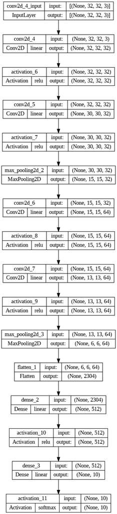

```python
cnn = generate_simple_cnn(X_train.shape[1:])
plot_model(cnn, show_shapes=True, show_layer_activations=True)
```

Then we need to setup for using GPU in training

```python
import tensorflow as tf

tf.config.list_physical_devices('GPU')
```

```
[PhysicalDevice(name='/physical_device:GPU:0', device_type='GPU')]
```

```python
config = tf.compat.v1.ConfigProto()
config.gpu_options.allow_growth = True
sess = tf.compat.v1.Session(config=config)
tf.compat.v1.keras.backend.set_session(sess)
```

I write a function called `train_model` which gets a Neural Network model, compile it and train it with given data. In the end, it gives information about model's accuracy, F1, precision and recall metrics. It also shows the confusion matrix of the model.

I used `adam`(Adaptive Moment Estimation) as optimizer instead of `SGD` (Stochastic Gradient Descent).

- `SGD` is a simple optimization algorithm that updates the weights based on the gradient of the loss function with respect to the weights. It computes the gradient on a small batch of training data and updates the weights in the direction of the negative gradient.
- `Adam` is a more complex optimization algorithm that combines the ideas of momentum and adaptive learning rates. It computes an exponentially weighted average of the past gradients and the past squared gradients and uses them to update the weights. This helps to smooth out the noise in the gradient, which can make the optimization more stable. Additionally, Adam adapts the learning rate for each weight based on the estimates of the variance and the mean of the gradients, which can help to converge faster and avoid getting stuck in local minima.

In summary, SGD is a simple and widely used optimization algorithm, but it can be slow to converge and sensitive to the choice of learning rate. Adam, on the other hand, is a more complex and computationally expensive algorithm, but it can converge faster and adaptively adjust the learning rate based on the gradient's statistics.

```python
import numpy as np
from sklearn.metrics import classification_report, confusion_matrix, f1_score, precision_score, recall_score

def train_model(model, x_train, y_train, x_test, y_test, batch_size = 32, epochs = 20):
    model.compile(loss = 'categorical_crossentropy', optimizer = 'adam', metrics = ['accuracy'])
    history = model.fit(x_train, y_train, batch_size=batch_size, epochs=epochs, validation_data=(x_test, y_test))

    plt.figure(figsize=(10, 4))
    plt.subplot(1, 2, 1)
    plt.plot(history.history['loss'], label='Training Loss')
    plt.plot(history.history['val_loss'], label='Validation Loss')
    plt.title('Training and Validation Loss')
    plt.xlabel('Epoch')
    plt.ylabel('Loss')
    plt.legend()
    plt.subplot(1, 2, 2)
    plt.plot(history.history['accuracy'], label='Training Accuracy')
    plt.plot(history.history['val_accuracy'], label='Validation Accuracy')
    plt.title('Training and Validation Accuracy')
    plt.xlabel('Epoch')
    plt.ylabel('Accuracy')
    plt.legend()
    plt.show()

    y_pred = model.predict(x_test)
    y_pred_classes = np.argmax(y_pred, axis=1)
    y_true = np.argmax(y_test_onehot, axis=1)
    class_labels = np.argmax(y_train, axis=1)
    class_names = ['airplane', 'automobile', 'bird', 'cat', 'deer',
               'dog', 'frog', 'horse', 'ship', 'truck']
    print('Classification Report:')
    print(classification_report(y_true, y_pred_classes, target_names=class_names))

    conf_matrix = confusion_matrix(y_true, y_pred_classes)
    plt.figure(figsize=(8, 6))
    plt.imshow(conf_matrix, cmap=plt.cm.Blues)
    plt.title('Confusion Matrix')
    plt.colorbar()
    tick_marks = np.arange(len(class_names))
    plt.xticks(tick_marks, class_names)
    plt.yticks(tick_marks, class_names)
    plt.xlabel('Predicted label')
    plt.ylabel('True label')
    plt.show()

    f1 = f1_score(y_true, y_pred_classes, average='weighted')
    precision = precision_score(y_true, y_pred_classes, average='weighted')
    recall = recall_score(y_true, y_pred_classes, average='weighted')
    print('F1 Score:', f1)
    print('Precision:', precision)
    print('Recall:', recall)
```

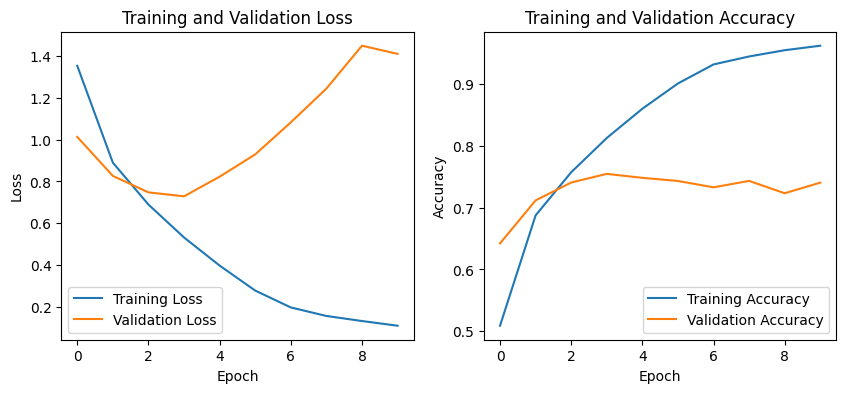

```
Classification Report:
              precision    recall  f1-score   support

    airplane       0.75      0.81      0.78      1000
  automobile       0.92      0.82      0.87      1000
        bird       0.62      0.64      0.63      1000
         cat       0.59      0.47      0.53      1000
        deer       0.69      0.69      0.69      1000
         dog       0.62      0.66      0.64      1000
        frog       0.76      0.84      0.80      1000
       horse       0.81      0.76      0.79      1000
        ship       0.85      0.85      0.85      1000
       truck       0.80      0.87      0.83      1000

    accuracy                           0.74     10000
   macro avg       0.74      0.74      0.74     10000
weighted avg       0.74      0.74      0.74     10000
```

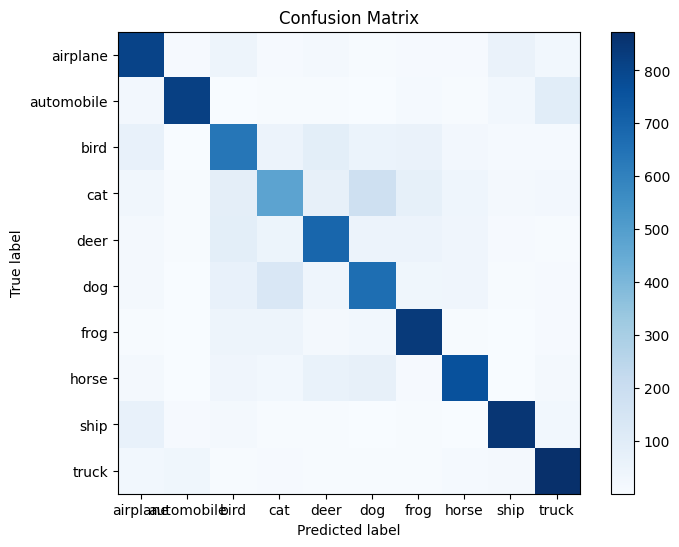

```
F1 Score: 0.7390470431058067
Precision: 0.7404259771882666
Recall: 0.7407
```

```python
train_model(cnn, X_train, y_train_onehot, X_test, y_test_onehot, epochs=10)
```

As you can see until the 4th epoch, the model was doing well both on test and train but after that it started to overfit.

## Part 2: Training a model with unbalanced data

In this part I removed 80% of the images related to `airplane` and `automobile` to see how it affects the training result of the model.

```python
airplane_idx, automobile_idx = 0, 1

automobile_indices = np.where(y_train == automobile_idx)[0]
airplane_indices = np.where(y_train == airplane_idx)[0]

remove_automobile = np.random.choice(automobile_indices, size=int(0.8*len(automobile_indices)), replace=False)
remove_airplane = np.random.choice(airplane_indices, size=int(0.8*len(airplane_indices)), replace=False)
remove_indices = np.concatenate((remove_automobile, remove_airplane))

remain_indices = np.setdiff1d(np.arange(len(y_train)), remove_indices)

reduced_y_train = y_train[remain_indices]
reduced_y_train_onehot = y_train_onehot[remain_indices]
reduced_X_train = X_train[remain_indices]
```

```python
cnn = generate_simple_cnn(X_train.shape[1:])
```

```
Model: "sequential_2"
_________________________________________________________________
 Layer (type)                Output Shape              Param #
=================================================================
 conv2d_8 (Conv2D)           (None, 32, 32, 32)        896

 activation_12 (Activation)  (None, 32, 32, 32)        0

 conv2d_9 (Conv2D)           (None, 30, 30, 32)        9248

 activation_13 (Activation)  (None, 30, 30, 32)        0

 max_pooling2d_4 (MaxPooling  (None, 15, 15, 32)       0
 2D)

 conv2d_10 (Conv2D)          (None, 15, 15, 64)        18496

 activation_14 (Activation)  (None, 15, 15, 64)        0

 conv2d_11 (Conv2D)          (None, 13, 13, 64)        36928

 activation_15 (Activation)  (None, 13, 13, 64)        0

 max_pooling2d_5 (MaxPooling  (None, 6, 6, 64)         0
 2D)

 flatten_2 (Flatten)         (None, 2304)              0

 dense_4 (Dense)             (None, 512)               1180160

 activation_16 (Activation)  (None, 512)               0

 dense_5 (Dense)             (None, 10)                5130

 activation_17 (Activation)  (None, 10)                0

=================================================================
Total params: 1,250,858
Trainable params: 1,250,858
Non-trainable params: 0
_________________________________________________________________
```

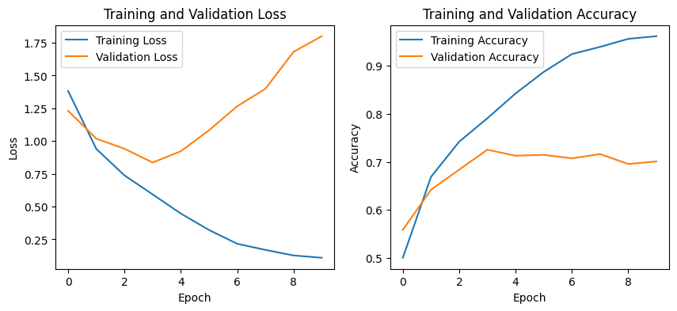

```
Classification Report:
              precision    recall  f1-score   support

    airplane       0.81      0.53      0.64      1000
  automobile       0.94      0.58      0.72      1000
        bird       0.61      0.63      0.62      1000
         cat       0.52      0.57      0.54      1000
        deer       0.68      0.71      0.70      1000
         dog       0.62      0.62      0.62      1000
        frog       0.72      0.84      0.77      1000
       horse       0.86      0.75      0.80      1000
        ship       0.74      0.88      0.80      1000
       truck       0.68      0.90      0.78      1000

    accuracy                           0.70     10000
   macro avg       0.72      0.70      0.70     10000
weighted avg       0.72      0.70      0.70     10000
```

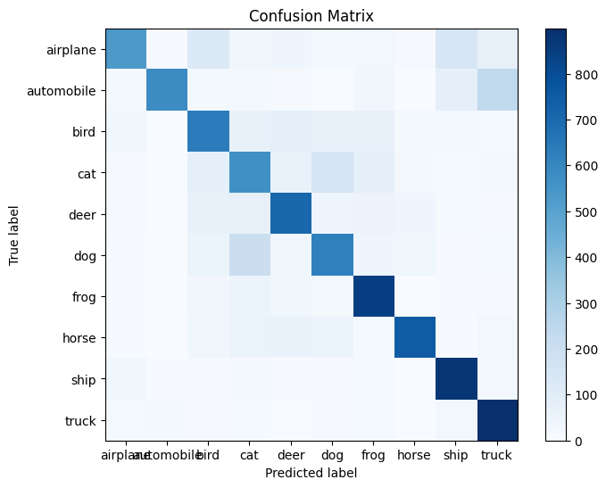

```
F1 Score: 0.6990451453598202
Precision: 0.7178244267615849
Recall: 0.7009
```

```python
train_model(cnn, reduced_X_train, reduced_y_train_onehot, X_test, y_test_onehot, epochs=10)
```

As you can see the genral metrics of the model has decreased and also the recall of `automobile` and `airplane` have dropped significantly. The reason is the model doesn't have enough data to be able to identify these two classes and probably predicts most of them as other classes so we get low recalls.

## Part 3: Data Augmentation

In this part I balanced the data using a technique called Data augmentation.

Data augmentation is a technique used in deep learning to artificially increase the size of the training set by generating new examples from the existing ones, typically through transformations such as rotation, translation, scaling, flipping, and/or color jittering.

I used keras' `ImageDataGenerator` for data augmentation. It changes the original images using various methods such as rotating, shifting or changing brightness.

```python
from keras.preprocessing.image import ImageDataGenerator
datagen = ImageDataGenerator(
    rotation_range=10,
    width_shift_range=0.05,
    height_shift_range=0.05,
    horizontal_flip=True,
    zoom_range=0.1,
    #brightness_range=[0.95,1.05]
)
```

```python
automobile_indices = np.where(reduced_y_train == automobile_idx)[0]
airplane_indices = np.where(reduced_y_train == airplane_idx)[0]
airplane_automobile_indices = np.concatenate((automobile_indices, airplane_indices))

airplane_automobile_imgs = reduced_X_train[airplane_automobile_indices]
airplane_automobile_labels = reduced_y_train[airplane_automobile_indices]

datagen.fit(airplane_automobile_imgs)

BATCH_SIZE = 32
num_augmented_images = 4*(len(automobile_indices) + len(airplane_indices))
augmented_imgs = []
augmented_labels = []
for i, (X_batch, y_batch) in enumerate(datagen.flow(airplane_automobile_imgs, airplane_automobile_labels, batch_size = BATCH_SIZE)):
    augmented_imgs.append(X_batch)
    augmented_labels.append(y_batch)
    if (i+1) * BATCH_SIZE > num_augmented_images:
      break

augmented_imgs = np.concatenate(augmented_imgs)
augmented_labels = np.concatenate(augmented_labels)
```

```python
augmented_X_train = np.concatenate((augmented_imgs, reduced_X_train))
augmented_y_train = np.concatenate((augmented_labels, reduced_y_train))
augmented_y_train_onehot = to_categorical(augmented_y_train)
```

Then I trained a new model on this data.

```python
cnn = generate_simple_cnn(augmented_X_train.shape[1:])
```

```
Model: "sequential_14"
_________________________________________________________________
 Layer (type)                Output Shape              Param #
=================================================================
 conv2d_60 (Conv2D)          (None, 32, 32, 32)        896

 activation_88 (Activation)  (None, 32, 32, 32)        0

 conv2d_61 (Conv2D)          (None, 30, 30, 32)        9248

 activation_89 (Activation)  (None, 30, 30, 32)        0

 max_pooling2d_30 (MaxPoolin  (None, 15, 15, 32)       0
 g2D)

 conv2d_62 (Conv2D)          (None, 15, 15, 64)        18496

 activation_90 (Activation)  (None, 15, 15, 64)        0

 conv2d_63 (Conv2D)          (None, 13, 13, 64)        36928

 activation_91 (Activation)  (None, 13, 13, 64)        0

 max_pooling2d_31 (MaxPoolin  (None, 6, 6, 64)         0
 g2D)

 flatten_14 (Flatten)        (None, 2304)              0

 dense_28 (Dense)            (None, 512)               1180160

 activation_92 (Activation)  (None, 512)               0

 dense_29 (Dense)            (None, 10)                5130

 activation_93 (Activation)  (None, 10)                0

=================================================================
Total params: 1,250,858
Trainable params: 1,250,858
Non-trainable params: 0
_________________________________________________________________
```

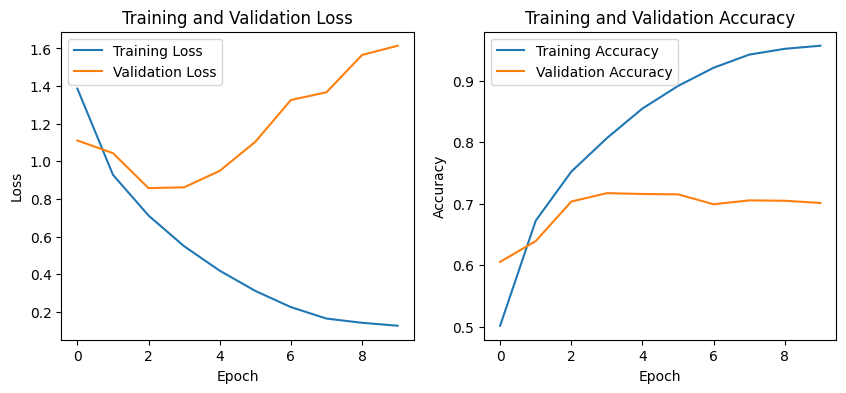

```
Classification Report:
              precision    recall  f1-score   support

    airplane       0.70      0.70      0.70      1000
  automobile       0.78      0.81      0.79      1000
        bird       0.62      0.59      0.61      1000
         cat       0.52      0.53      0.52      1000
        deer       0.71      0.63      0.67      1000
         dog       0.59      0.65      0.62      1000
        frog       0.84      0.72      0.78      1000
       horse       0.77      0.77      0.77      1000
        ship       0.75      0.83      0.79      1000
       truck       0.76      0.79      0.77      1000

    accuracy                           0.70     10000
   macro avg       0.70      0.70      0.70     10000
weighted avg       0.70      0.70      0.70     10000
```

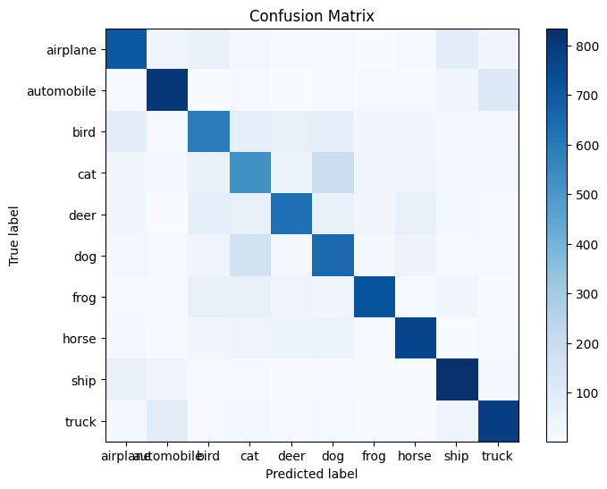

```
F1 Score: 0.7011997043870085
Precision: 0.7032472225436392
Recall: 0.7014
```

```python
train_model(cnn, augmented_X_train, augmented_y_train_onehot, X_test, y_test_onehot, epochs=10)
```

As you can see the F1 and recall of automobile and airplane are better than part 2 and the reason is we have more data for them in training. However, The F1 and recall and the model's general accuracy is still lower than part 1 which makes sense because in this part we used our remaining images to generate more images.

## Part 4: Impact of Regularization Techniques in Training Result

There are two techniques that can be used to improve the Netwrok's Acurracy:

- `Dropout` is a regularization technique used in deep learning to prevent overfitting. It randomly drops out (sets to zero) some of the neurons in a layer during training, which forces the remaining neurons to learn more robust and independent features. Dropout can improve the generalization performance of the model.
- `Batch Normalization` is a technique used in deep learning to normalize the inputs of each layer to have zero mean and unit variance. This improves the distribution in inputs of each layer and makes the optimization more stable and make the convergence faster. Batch normalization can improve the accuracy and speed of the training process.

I made some chnages to the network of part 1:

- I added two Convolutional layers with 128 filters.
- I added a Batch Normalization layer after each Convolutional layer.
- I added a Dropout after two consecutive Convolutional layers.
- I also added a Dropout after the dense layer.

```python
from tensorflow.keras.layers import BatchNormalization

def generate_complex_cnn(input_shape):
    cnn = Sequential()
    cnn.add(Conv2D(32, (3, 3), padding='same', activation="relu", input_shape=input_shape))
    cnn.add(Activation('relu'))
    cnn.add(BatchNormalization())
    cnn.add(Conv2D(32, (3, 3)))
    cnn.add(Activation('relu'))
    cnn.add(BatchNormalization())
    cnn.add(MaxPooling2D(pool_size=(2, 2)))
    cnn.add(Dropout(0.25))

    cnn.add(Conv2D(64, (3, 3), padding='same', activation="relu", input_shape=input_shape))
    cnn.add(Activation('relu'))
    cnn.add(BatchNormalization())
    cnn.add(Conv2D(64, (3, 3)))
    cnn.add(Activation('relu'))
    cnn.add(BatchNormalization())
    cnn.add(MaxPooling2D(pool_size=(2, 2)))
    cnn.add(Dropout(0.25))

    cnn.add(Conv2D(128, (3, 3), padding='same', activation="relu", input_shape=input_shape))
    cnn.add(Activation('relu'))
    cnn.add(BatchNormalization())
    cnn.add(Conv2D(128, (3, 3)))
    cnn.add(Activation('relu'))
    cnn.add(BatchNormalization())
    cnn.add(MaxPooling2D(pool_size=(2, 2)))
    cnn.add(Dropout(0.25))

    cnn.add(Flatten())
    cnn.add(Dense(256))
    cnn.add(Activation('relu'))
    cnn.add(Dropout(0.25))
    cnn.add(Dense(10))
    cnn.add(Activation('softmax'))

    cnn.summary()
    #plot_model(cnn, show_shapes=True)
    plt.show()
    return cnn
```

```
Model: "sequential_10"
_________________________________________________________________
 Layer (type)                Output Shape              Param #
=================================================================
 conv2d_42 (Conv2D)          (None, 32, 32, 32)        896

 activation_62 (Activation)  (None, 32, 32, 32)        0

 batch_normalization_6 (Batc  (None, 32, 32, 32)       128
 hNormalization)

 conv2d_43 (Conv2D)          (None, 30, 30, 32)        9248

 activation_63 (Activation)  (None, 30, 30, 32)        0

 batch_normalization_7 (Batc  (None, 30, 30, 32)       128
 hNormalization)

 max_pooling2d_21 (MaxPoolin  (None, 15, 15, 32)       0
 g2D)

 dropout_4 (Dropout)         (None, 15, 15, 32)        0

 conv2d_44 (Conv2D)          (None, 15, 15, 64)        18496

 activation_64 (Activation)  (None, 15, 15, 64)        0

 batch_normalization_8 (Batc  (None, 15, 15, 64)       256
 hNormalization)

 conv2d_45 (Conv2D)          (None, 13, 13, 64)        36928

 activation_65 (Activation)  (None, 13, 13, 64)        0

 batch_normalization_9 (Batc  (None, 13, 13, 64)       256
 hNormalization)

 max_pooling2d_22 (MaxPoolin  (None, 6, 6, 64)         0
 g2D)

```

[output cut: 23 more lines]

```
 dense_20 (Dense)            (None, 256)               131328

 activation_68 (Activation)  (None, 256)               0

 dropout_7 (Dropout)         (None, 256)               0

 dense_21 (Dense)            (None, 10)                2570

 activation_69 (Activation)  (None, 10)                0

=================================================================
Total params: 422,698
Trainable params: 421,802
Non-trainable params: 896
_________________________________________________________________
```

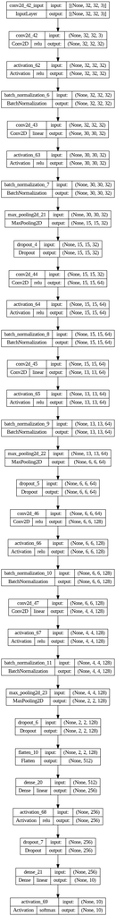

```python
cnn = generate_complex_cnn(X_train.shape[1:])
plot_model(cnn, show_shapes=True, show_layer_activations=True)
```

I trained these model on the original data to compare it with my first model.

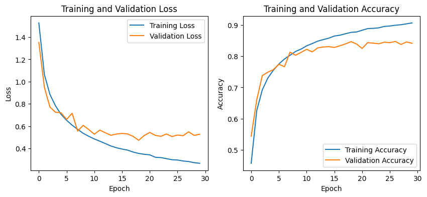

```
Classification Report:
              precision    recall  f1-score   support

    airplane       0.93      0.77      0.84      1000
  automobile       0.95      0.89      0.92      1000
        bird       0.81      0.75      0.78      1000
         cat       0.75      0.70      0.72      1000
        deer       0.72      0.93      0.81      1000
         dog       0.82      0.76      0.78      1000
        frog       0.80      0.93      0.86      1000
       horse       0.92      0.85      0.89      1000
        ship       0.90      0.93      0.91      1000
       truck       0.88      0.92      0.90      1000

    accuracy                           0.84     10000
   macro avg       0.85      0.84      0.84     10000
weighted avg       0.85      0.84      0.84     10000
```

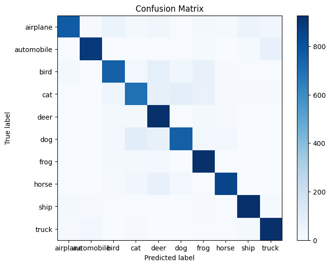

```
F1 Score: 0.8410405485213754
Precision: 0.8469257590142899
Recall: 0.8414
```

```python
train_model(cnn, X_train, y_train_onehot, X_test, y_test_onehot, epochs=30)
```

As you can see the model's accuracy increases more smoothly per epoch and test acurracy doesn't stop increasing after 4 epochs anymore. it also doesn't overfit anymore like the first model.